# Risk Factor Analysis

## Outcome Variable

**Outcome Variable:** ever_stunted

## Predictor Variables

**Intervention Variable:** vagbrth

**Adjustment Set:**

unadjusted

## Stratifying Variables

The analysis was stratified on these variable(s):

- agecat
- studyid
- country

## Data Summary

| agecat | studyid | country | A | n | nA | nAY0 | nAY1 |
| --- | --- | --- | --- | --- | --- | --- | --- |
| 3 months | ki1000108-CMC-V-BCS-2002 | INDIA | 0 | 362 | 25 | 16 | 9 |
| 3 months | ki1000108-CMC-V-BCS-2002 | INDIA | 1 | 362 | 337 | 221 | 116 |
| 3 months | ki1000108-IRC | INDIA | 0 | 410 | 70 | 43 | 27 |
| 3 months | ki1000108-IRC | INDIA | 1 | 410 | 340 | 237 | 103 |
| 3 months | ki1017093b-PROVIDE | BANGLADESH | 0 | 700 | 160 | 133 | 27 |
| 3 months | ki1017093b-PROVIDE | BANGLADESH | 1 | 700 | 540 | 437 | 103 |
| 3 months | ki1017093c-NIH-Crypto | BANGLADESH | 0 | 500 | 204 | 171 | 33 |
| 3 months | ki1017093c-NIH-Crypto | BANGLADESH | 1 | 500 | 296 | 245 | 51 |
| 3 months | ki1066203-TanzaniaChild2 | TANZANIA, UNITED REPUBLIC OF | 0 | 2364 | 212 | 186 | 26 |
| 3 months | ki1066203-TanzaniaChild2 | TANZANIA, UNITED REPUBLIC OF | 1 | 2364 | 2152 | 1935 | 217 |
| 3 months | ki1126311-ZVITAMBO | ZIMBABWE | 0 | 13917 | 1176 | 949 | 227 |
| 3 months | ki1126311-ZVITAMBO | ZIMBABWE | 1 | 13917 | 12741 | 10059 | 2682 |
| 6 months | ki1000108-CMC-V-BCS-2002 | INDIA | 0 | 367 | 25 | 12 | 13 |
| 6 months | ki1000108-CMC-V-BCS-2002 | INDIA | 1 | 367 | 342 | 167 | 175 |
| 6 months | ki1000108-IRC | INDIA | 0 | 408 | 70 | 35 | 35 |
| 6 months | ki1000108-IRC | INDIA | 1 | 408 | 338 | 200 | 138 |
| 6 months | ki1017093b-PROVIDE | BANGLADESH | 0 | 640 | 147 | 114 | 33 |
| 6 months | ki1017093b-PROVIDE | BANGLADESH | 1 | 640 | 493 | 363 | 130 |
| 6 months | ki1017093c-NIH-Crypto | BANGLADESH | 0 | 478 | 196 | 140 | 56 |
| 6 months | ki1017093c-NIH-Crypto | BANGLADESH | 1 | 478 | 282 | 189 | 93 |
| 6 months | ki1066203-TanzaniaChild2 | TANZANIA, UNITED REPUBLIC OF | 0 | 2207 | 203 | 160 | 43 |
| 6 months | ki1066203-TanzaniaChild2 | TANZANIA, UNITED REPUBLIC OF | 1 | 2207 | 2004 | 1602 | 402 |
| 6 months | ki1126311-ZVITAMBO | ZIMBABWE | 0 | 9035 | 762 | 560 | 202 |
| 6 months | ki1126311-ZVITAMBO | ZIMBABWE | 1 | 9035 | 8273 | 5814 | 2459 |
| 12 months | ki1000108-CMC-V-BCS-2002 | INDIA | 0 | 372 | 24 | 5 | 19 |
| 12 months | ki1000108-CMC-V-BCS-2002 | INDIA | 1 | 372 | 348 | 107 | 241 |
| 12 months | ki1000108-IRC | INDIA | 0 | 408 | 70 | 31 | 39 |
| 12 months | ki1000108-IRC | INDIA | 1 | 408 | 338 | 170 | 168 |
| 12 months | ki1017093b-PROVIDE | BANGLADESH | 0 | 609 | 141 | 105 | 36 |
| 12 months | ki1017093b-PROVIDE | BANGLADESH | 1 | 609 | 468 | 302 | 166 |
| 12 months | ki1017093c-NIH-Crypto | BANGLADESH | 0 | 471 | 194 | 127 | 67 |
| 12 months | ki1017093c-NIH-Crypto | BANGLADESH | 1 | 471 | 277 | 159 | 118 |
| 12 months | ki1066203-TanzaniaChild2 | TANZANIA, UNITED REPUBLIC OF | 0 | 1974 | 184 | 133 | 51 |
| 12 months | ki1066203-TanzaniaChild2 | TANZANIA, UNITED REPUBLIC OF | 1 | 1974 | 1790 | 1214 | 576 |
| 12 months | ki1126311-ZVITAMBO | ZIMBABWE | 0 | 10098 | 855 | 537 | 318 |
| 12 months | ki1126311-ZVITAMBO | ZIMBABWE | 1 | 10098 | 9243 | 5757 | 3486 |
| 18 months | ki1000108-CMC-V-BCS-2002 | INDIA | 0 | 373 | 25 | 4 | 21 |
| 18 months | ki1000108-CMC-V-BCS-2002 | INDIA | 1 | 373 | 348 | 53 | 295 |
| 18 months | ki1000108-IRC | INDIA | 0 | 409 | 70 | 29 | 41 |
| 18 months | ki1000108-IRC | INDIA | 1 | 409 | 339 | 150 | 189 |
| 18 months | ki1017093b-PROVIDE | BANGLADESH | 0 | 604 | 140 | 88 | 52 |
| 18 months | ki1017093b-PROVIDE | BANGLADESH | 1 | 604 | 464 | 264 | 200 |
| 18 months | ki1017093c-NIH-Crypto | BANGLADESH | 0 | 459 | 189 | 117 | 72 |
| 18 months | ki1017093c-NIH-Crypto | BANGLADESH | 1 | 459 | 270 | 130 | 140 |
| 18 months | ki1066203-TanzaniaChild2 | TANZANIA, UNITED REPUBLIC OF | 0 | 1435 | 140 | 93 | 47 |
| 18 months | ki1066203-TanzaniaChild2 | TANZANIA, UNITED REPUBLIC OF | 1 | 1435 | 1295 | 762 | 533 |
| 18 months | ki1126311-ZVITAMBO | ZIMBABWE | 0 | 7226 | 609 | 313 | 296 |
| 18 months | ki1126311-ZVITAMBO | ZIMBABWE | 1 | 7226 | 6617 | 3372 | 3245 |
| 24 months | ki1000108-CMC-V-BCS-2002 | INDIA | 0 | 373 | 25 | 3 | 22 |
| 24 months | ki1000108-CMC-V-BCS-2002 | INDIA | 1 | 373 | 348 | 25 | 323 |
| 24 months | ki1000108-IRC | INDIA | 0 | 410 | 70 | 24 | 46 |
| 24 months | ki1000108-IRC | INDIA | 1 | 410 | 340 | 123 | 217 |
| 24 months | ki1017093b-PROVIDE | BANGLADESH | 0 | 582 | 135 | 77 | 58 |
| 24 months | ki1017093b-PROVIDE | BANGLADESH | 1 | 582 | 447 | 225 | 222 |
| 24 months | ki1017093c-NIH-Crypto | BANGLADESH | 0 | 380 | 150 | 78 | 72 |
| 24 months | ki1017093c-NIH-Crypto | BANGLADESH | 1 | 380 | 230 | 98 | 132 |
| 24 months | ki1066203-TanzaniaChild2 | TANZANIA, UNITED REPUBLIC OF | 0 | 949 | 92 | 58 | 34 |
| 24 months | ki1066203-TanzaniaChild2 | TANZANIA, UNITED REPUBLIC OF | 1 | 949 | 857 | 481 | 376 |
| 24 months | ki1126311-ZVITAMBO | ZIMBABWE | 0 | 1861 | 153 | 54 | 99 |
| 24 months | ki1126311-ZVITAMBO | ZIMBABWE | 1 | 1861 | 1708 | 473 | 1235 |

The following strata were considered:

- agecat: 12 months, studyid: ki1000108-CMC-V-BCS-2002, country: INDIA
- agecat: 12 months, studyid: ki1000108-IRC, country: INDIA
- agecat: 12 months, studyid: ki1017093b-PROVIDE, country: BANGLADESH
- agecat: 12 months, studyid: ki1017093c-NIH-Crypto, country: BANGLADESH
- agecat: 12 months, studyid: ki1066203-TanzaniaChild2, country: TANZANIA, UNITED REPUBLIC OF
- agecat: 12 months, studyid: ki1126311-ZVITAMBO, country: ZIMBABWE
- agecat: 18 months, studyid: ki1000108-CMC-V-BCS-2002, country: INDIA
- agecat: 18 months, studyid: ki1000108-IRC, country: INDIA
- agecat: 18 months, studyid: ki1017093b-PROVIDE, country: BANGLADESH
- agecat: 18 months, studyid: ki1017093c-NIH-Crypto, country: BANGLADESH
- agecat: 18 months, studyid: ki1066203-TanzaniaChild2, country: TANZANIA, UNITED REPUBLIC OF
- agecat: 18 months, studyid: ki1126311-ZVITAMBO, country: ZIMBABWE
- agecat: 24 months, studyid: ki1000108-CMC-V-BCS-2002, country: INDIA
- agecat: 24 months, studyid: ki1000108-IRC, country: INDIA
- agecat: 24 months, studyid: ki1017093b-PROVIDE, country: BANGLADESH
- agecat: 24 months, studyid: ki1017093c-NIH-Crypto, country: BANGLADESH
- agecat: 24 months, studyid: ki1066203-TanzaniaChild2, country: TANZANIA, UNITED REPUBLIC OF
- agecat: 24 months, studyid: ki1126311-ZVITAMBO, country: ZIMBABWE
- agecat: 3 months, studyid: ki1000108-CMC-V-BCS-2002, country: INDIA
- agecat: 3 months, studyid: ki1000108-IRC, country: INDIA
- agecat: 3 months, studyid: ki1017093b-PROVIDE, country: BANGLADESH
- agecat: 3 months, studyid: ki1017093c-NIH-Crypto, country: BANGLADESH
- agecat: 3 months, studyid: ki1066203-TanzaniaChild2, country: TANZANIA, UNITED REPUBLIC OF
- agecat: 3 months, studyid: ki1126311-ZVITAMBO, country: ZIMBABWE
- agecat: 6 months, studyid: ki1000108-CMC-V-BCS-2002, country: INDIA
- agecat: 6 months, studyid: ki1000108-IRC, country: INDIA
- agecat: 6 months, studyid: ki1017093b-PROVIDE, country: BANGLADESH
- agecat: 6 months, studyid: ki1017093c-NIH-Crypto, country: BANGLADESH
- agecat: 6 months, studyid: ki1066203-TanzaniaChild2, country: TANZANIA, UNITED REPUBLIC OF
- agecat: 6 months, studyid: ki1126311-ZVITAMBO, country: ZIMBABWE

### Dropped Strata

Some strata were dropped due to rare outcomes:

- agecat: 18 months, studyid: ki1000108-CMC-V-BCS-2002, country: INDIA
- agecat: 24 months, studyid: ki1000108-CMC-V-BCS-2002, country: INDIA

## Methods Detail

We’re interested in the causal parameters $E[Y_a]$ for all values of $a \in \mathcal{A}$. These parameters represent the mean outcome if, possibly contrary to fact, we intervened to set all units to have $A=a$. Under the randomization and positivity assumptions, these are identified by the statistical parameters $\psi_a=E_W[E_{Y|A,W}(Y|A=a,W)]$. In addition, we’re interested in the mean of $Y$, $E[Y]$ under no intervention (the observed mean). We will estimate these parameters by using SuperLearner to fit the relevant likelihood factors – $E_{Y|A,W}(Y|A=a,W)$ and $p(A=a|W)$, and then updating our likelihood fit using a joint TMLE.

For unadjusted analyses ($W=\{\}$), initial likelihoods were estimated using Lrnr_glm to estimate the simple $E(Y|A)$ and Lrnr_mean to estimate $p(A)$. For adjusted analyses, a small library containing Lrnr_glmnet, Lrnr_xgboost, and Lrnr_mean was used.

Having estimated these parameters, we will then use the delta method to estimate relative risks and attributable risks relative to a prespecified baseline level of $A$.

# Results Detail

## Results Plots

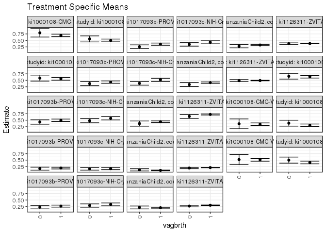

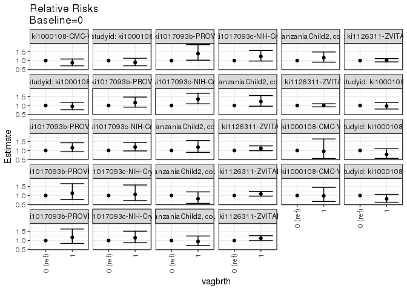

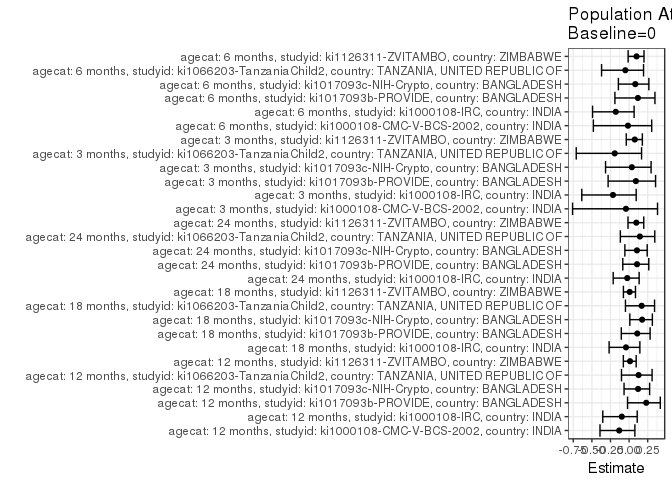

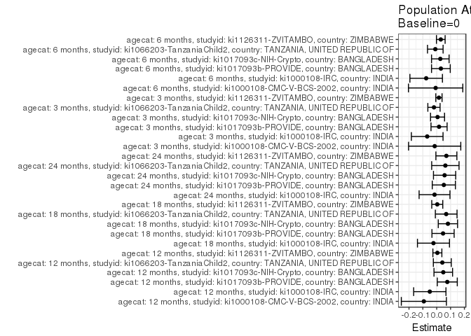

## Results Table

### Parameter: TSM

| agecat | studyid | country | intervention_level | baseline_level | estimate | ci_lower | ci_upper |
| --- | --- | --- | --- | --- | --- | --- | --- |
| 3 months | ki1000108-CMC-V-BCS-2002 | INDIA | 0 | NA | 0.3600000 | 0.1715830 | 0.5484170 |
| 3 months | ki1000108-CMC-V-BCS-2002 | INDIA | 1 | NA | 0.3442136 | 0.2934177 | 0.3950096 |
| 3 months | ki1000108-IRC | INDIA | 0 | NA | 0.3857143 | 0.2715455 | 0.4998831 |
| 3 months | ki1000108-IRC | INDIA | 1 | NA | 0.3029412 | 0.2540362 | 0.3518461 |
| 3 months | ki1017093b-PROVIDE | BANGLADESH | 0 | NA | 0.1687500 | 0.1106754 | 0.2268246 |
| 3 months | ki1017093b-PROVIDE | BANGLADESH | 1 | NA | 0.1907407 | 0.1575798 | 0.2239017 |
| 3 months | ki1017093c-NIH-Crypto | BANGLADESH | 0 | NA | 0.1617647 | 0.1111831 | 0.2123463 |
| 3 months | ki1017093c-NIH-Crypto | BANGLADESH | 1 | NA | 0.1722973 | 0.1292334 | 0.2153612 |
| 3 months | ki1066203-TanzaniaChild2 | TANZANIA, UNITED REPUBLIC OF | 0 | NA | 0.1226415 | 0.0784764 | 0.1668066 |
| 3 months | ki1066203-TanzaniaChild2 | TANZANIA, UNITED REPUBLIC OF | 1 | NA | 0.1008364 | 0.0881118 | 0.1135611 |
| 3 months | ki1126311-ZVITAMBO | ZIMBABWE | 0 | NA | 0.1930272 | 0.1704693 | 0.2155851 |
| 3 months | ki1126311-ZVITAMBO | ZIMBABWE | 1 | NA | 0.2105015 | 0.2034226 | 0.2175804 |
| 6 months | ki1000108-CMC-V-BCS-2002 | INDIA | 0 | NA | 0.5200000 | 0.3238931 | 0.7161069 |
| 6 months | ki1000108-CMC-V-BCS-2002 | INDIA | 1 | NA | 0.5116959 | 0.4586467 | 0.5647451 |
| 6 months | ki1000108-IRC | INDIA | 0 | NA | 0.5000000 | 0.3827259 | 0.6172741 |
| 6 months | ki1000108-IRC | INDIA | 1 | NA | 0.4082840 | 0.3558201 | 0.4607479 |
| 6 months | ki1017093b-PROVIDE | BANGLADESH | 0 | NA | 0.2244898 | 0.1569871 | 0.2919925 |
| 6 months | ki1017093b-PROVIDE | BANGLADESH | 1 | NA | 0.2636917 | 0.2247655 | 0.3026179 |
| 6 months | ki1017093c-NIH-Crypto | BANGLADESH | 0 | NA | 0.2857143 | 0.2224036 | 0.3490249 |
| 6 months | ki1017093c-NIH-Crypto | BANGLADESH | 1 | NA | 0.3297872 | 0.2748583 | 0.3847162 |
| 6 months | ki1066203-TanzaniaChild2 | TANZANIA, UNITED REPUBLIC OF | 0 | NA | 0.2118227 | 0.1556019 | 0.2680434 |
| 6 months | ki1066203-TanzaniaChild2 | TANZANIA, UNITED REPUBLIC OF | 1 | NA | 0.2005988 | 0.1830623 | 0.2181354 |
| 6 months | ki1126311-ZVITAMBO | ZIMBABWE | 0 | NA | 0.2650919 | 0.2337511 | 0.2964326 |
| 6 months | ki1126311-ZVITAMBO | ZIMBABWE | 1 | NA | 0.2972320 | 0.2873829 | 0.3070810 |
| 12 months | ki1000108-CMC-V-BCS-2002 | INDIA | 0 | NA | 0.7916667 | 0.6289704 | 0.9543629 |
| 12 months | ki1000108-CMC-V-BCS-2002 | INDIA | 1 | NA | 0.6925287 | 0.6439815 | 0.7410759 |
| 12 months | ki1000108-IRC | INDIA | 0 | NA | 0.5571429 | 0.4406372 | 0.6736485 |
| 12 months | ki1000108-IRC | INDIA | 1 | NA | 0.4970414 | 0.4436729 | 0.5504099 |
| 12 months | ki1017093b-PROVIDE | BANGLADESH | 0 | NA | 0.2553191 | 0.1832877 | 0.3273506 |
| 12 months | ki1017093b-PROVIDE | BANGLADESH | 1 | NA | 0.3547009 | 0.3113204 | 0.3980813 |
| 12 months | ki1017093c-NIH-Crypto | BANGLADESH | 0 | NA | 0.3453608 | 0.2783806 | 0.4123410 |
| 12 months | ki1017093c-NIH-Crypto | BANGLADESH | 1 | NA | 0.4259928 | 0.3676980 | 0.4842875 |
| 12 months | ki1066203-TanzaniaChild2 | TANZANIA, UNITED REPUBLIC OF | 0 | NA | 0.2771739 | 0.2124831 | 0.3418647 |
| 12 months | ki1066203-TanzaniaChild2 | TANZANIA, UNITED REPUBLIC OF | 1 | NA | 0.3217877 | 0.3001406 | 0.3434348 |
| 12 months | ki1126311-ZVITAMBO | ZIMBABWE | 0 | NA | 0.3719298 | 0.3395316 | 0.4043280 |
| 12 months | ki1126311-ZVITAMBO | ZIMBABWE | 1 | NA | 0.3771503 | 0.3672690 | 0.3870315 |
| 18 months | ki1000108-IRC | INDIA | 0 | NA | 0.5857143 | 0.4701766 | 0.7012519 |
| 18 months | ki1000108-IRC | INDIA | 1 | NA | 0.5575221 | 0.5045855 | 0.6104588 |
| 18 months | ki1017093b-PROVIDE | BANGLADESH | 0 | NA | 0.3714286 | 0.2913237 | 0.4515334 |
| 18 months | ki1017093b-PROVIDE | BANGLADESH | 1 | NA | 0.4310345 | 0.3859375 | 0.4761315 |
| 18 months | ki1017093c-NIH-Crypto | BANGLADESH | 0 | NA | 0.3809524 | 0.3116436 | 0.4502611 |
| 18 months | ki1017093c-NIH-Crypto | BANGLADESH | 1 | NA | 0.5185185 | 0.4588546 | 0.5781824 |
| 18 months | ki1066203-TanzaniaChild2 | TANZANIA, UNITED REPUBLIC OF | 0 | NA | 0.3357143 | 0.2574619 | 0.4139667 |
| 18 months | ki1066203-TanzaniaChild2 | TANZANIA, UNITED REPUBLIC OF | 1 | NA | 0.4115830 | 0.3847706 | 0.4383954 |
| 18 months | ki1126311-ZVITAMBO | ZIMBABWE | 0 | NA | 0.4860427 | 0.4463445 | 0.5257408 |
| 18 months | ki1126311-ZVITAMBO | ZIMBABWE | 1 | NA | 0.4904035 | 0.4783577 | 0.5024494 |
| 24 months | ki1000108-IRC | INDIA | 0 | NA | 0.6571429 | 0.5458119 | 0.7684738 |
| 24 months | ki1000108-IRC | INDIA | 1 | NA | 0.6382353 | 0.5870975 | 0.6893731 |
| 24 months | ki1017093b-PROVIDE | BANGLADESH | 0 | NA | 0.4296296 | 0.3460539 | 0.5132054 |
| 24 months | ki1017093b-PROVIDE | BANGLADESH | 1 | NA | 0.4966443 | 0.4502539 | 0.5430347 |
| 24 months | ki1017093c-NIH-Crypto | BANGLADESH | 0 | NA | 0.4800000 | 0.3999434 | 0.5600566 |
| 24 months | ki1017093c-NIH-Crypto | BANGLADESH | 1 | NA | 0.5739130 | 0.5099206 | 0.6379055 |
| 24 months | ki1066203-TanzaniaChild2 | TANZANIA, UNITED REPUBLIC OF | 0 | NA | 0.3695652 | 0.2708808 | 0.4682497 |
| 24 months | ki1066203-TanzaniaChild2 | TANZANIA, UNITED REPUBLIC OF | 1 | NA | 0.4387398 | 0.4054989 | 0.4719807 |
| 24 months | ki1126311-ZVITAMBO | ZIMBABWE | 0 | NA | 0.6470588 | 0.5713159 | 0.7228018 |
| 24 months | ki1126311-ZVITAMBO | ZIMBABWE | 1 | NA | 0.7230679 | 0.7018405 | 0.7442953 |

### Parameter: E(Y)

| agecat | studyid | country | intervention_level | baseline_level | estimate | ci_lower | ci_upper |
| --- | --- | --- | --- | --- | --- | --- | --- |
| 3 months | ki1000108-CMC-V-BCS-2002 | INDIA | NA | NA | 0.3453039 | 0.3448910 | 0.3457168 |
| 3 months | ki1000108-IRC | INDIA | NA | NA | 0.3170732 | 0.3140547 | 0.3200916 |
| 3 months | ki1017093b-PROVIDE | BANGLADESH | NA | NA | 0.1857143 | 0.1850297 | 0.1863988 |
| 3 months | ki1017093c-NIH-Crypto | BANGLADESH | NA | NA | 0.1680000 | 0.1675458 | 0.1684542 |
| 3 months | ki1066203-TanzaniaChild2 | TANZANIA, UNITED REPUBLIC OF | NA | NA | 0.1027919 | 0.1025407 | 0.1030431 |
| 3 months | ki1126311-ZVITAMBO | ZIMBABWE | NA | NA | 0.2090249 | 0.2089442 | 0.2091057 |
| 6 months | ki1000108-CMC-V-BCS-2002 | INDIA | NA | NA | 0.5122616 | 0.5120472 | 0.5124759 |
| 6 months | ki1000108-IRC | INDIA | NA | NA | 0.4240196 | 0.4206604 | 0.4273789 |
| 6 months | ki1017093b-PROVIDE | BANGLADESH | NA | NA | 0.2546875 | 0.2534090 | 0.2559660 |
| 6 months | ki1017093c-NIH-Crypto | BANGLADESH | NA | NA | 0.3117155 | 0.3097702 | 0.3136608 |
| 6 months | ki1066203-TanzaniaChild2 | TANZANIA, UNITED REPUBLIC OF | NA | NA | 0.2016312 | 0.2014958 | 0.2017665 |
| 6 months | ki1126311-ZVITAMBO | ZIMBABWE | NA | NA | 0.2945213 | 0.2943371 | 0.2947055 |
| 12 months | ki1000108-CMC-V-BCS-2002 | INDIA | NA | NA | 0.6989247 | 0.6964464 | 0.7014030 |
| 12 months | ki1000108-IRC | INDIA | NA | NA | 0.5073529 | 0.5051516 | 0.5095543 |
| 12 months | ki1017093b-PROVIDE | BANGLADESH | NA | NA | 0.3316913 | 0.3283592 | 0.3350234 |
| 12 months | ki1017093c-NIH-Crypto | BANGLADESH | NA | NA | 0.3927813 | 0.3891935 | 0.3963691 |
| 12 months | ki1066203-TanzaniaChild2 | TANZANIA, UNITED REPUBLIC OF | NA | NA | 0.3176292 | 0.3170569 | 0.3182015 |
| 12 months | ki1126311-ZVITAMBO | ZIMBABWE | NA | NA | 0.3767083 | 0.3766799 | 0.3767366 |
| 18 months | ki1000108-IRC | INDIA | NA | NA | 0.5623472 | 0.5613169 | 0.5633775 |
| 18 months | ki1017093b-PROVIDE | BANGLADESH | NA | NA | 0.4172185 | 0.4152110 | 0.4192261 |
| 18 months | ki1017093c-NIH-Crypto | BANGLADESH | NA | NA | 0.4618736 | 0.4556731 | 0.4680741 |
| 18 months | ki1066203-TanzaniaChild2 | TANZANIA, UNITED REPUBLIC OF | NA | NA | 0.4041812 | 0.4030160 | 0.4053463 |
| 18 months | ki1126311-ZVITAMBO | ZIMBABWE | NA | NA | 0.4900360 | 0.4900080 | 0.4900639 |
| 24 months | ki1000108-IRC | INDIA | NA | NA | 0.6414634 | 0.6407739 | 0.6421529 |
| 24 months | ki1017093b-PROVIDE | BANGLADESH | NA | NA | 0.4810997 | 0.4787997 | 0.4833997 |
| 24 months | ki1017093c-NIH-Crypto | BANGLADESH | NA | NA | 0.5368421 | 0.5322206 | 0.5414636 |
| 24 months | ki1066203-TanzaniaChild2 | TANZANIA, UNITED REPUBLIC OF | NA | NA | 0.4320337 | 0.4307308 | 0.4333366 |
| 24 months | ki1126311-ZVITAMBO | ZIMBABWE | NA | NA | 0.7168189 | 0.7158701 | 0.7177678 |

### Parameter: RR

| agecat | studyid | country | intervention_level | baseline_level | estimate | ci_lower | ci_upper |
| --- | --- | --- | --- | --- | --- | --- | --- |
| 3 months | ki1000108-CMC-V-BCS-2002 | INDIA | 0 | 0 | 1.0000000 | 1.0000000 | 1.000000 |
| 3 months | ki1000108-CMC-V-BCS-2002 | INDIA | 1 | 0 | 0.9561490 | 0.5550881 | 1.646984 |
| 3 months | ki1000108-IRC | INDIA | 0 | 0 | 1.0000000 | 1.0000000 | 1.000000 |
| 3 months | ki1000108-IRC | INDIA | 1 | 0 | 0.7854031 | 0.5606198 | 1.100314 |
| 3 months | ki1017093b-PROVIDE | BANGLADESH | 0 | 0 | 1.0000000 | 1.0000000 | 1.000000 |
| 3 months | ki1017093b-PROVIDE | BANGLADESH | 1 | 0 | 1.1303155 | 0.7686884 | 1.662069 |
| 3 months | ki1017093c-NIH-Crypto | BANGLADESH | 0 | 0 | 1.0000000 | 1.0000000 | 1.000000 |
| 3 months | ki1017093c-NIH-Crypto | BANGLADESH | 1 | 0 | 1.0651106 | 0.7137487 | 1.589440 |
| 3 months | ki1066203-TanzaniaChild2 | TANZANIA, UNITED REPUBLIC OF | 0 | 0 | 1.0000000 | 1.0000000 | 1.000000 |
| 3 months | ki1066203-TanzaniaChild2 | TANZANIA, UNITED REPUBLIC OF | 1 | 0 | 0.8222048 | 0.5613834 | 1.204205 |
| 3 months | ki1126311-ZVITAMBO | ZIMBABWE | 0 | 0 | 1.0000000 | 1.0000000 | 1.000000 |
| 3 months | ki1126311-ZVITAMBO | ZIMBABWE | 1 | 0 | 1.0905278 | 0.9656591 | 1.231543 |
| 6 months | ki1000108-CMC-V-BCS-2002 | INDIA | 0 | 0 | 1.0000000 | 1.0000000 | 1.000000 |
| 6 months | ki1000108-CMC-V-BCS-2002 | INDIA | 1 | 0 | 0.9840306 | 0.6654995 | 1.455022 |
| 6 months | ki1000108-IRC | INDIA | 0 | 0 | 1.0000000 | 1.0000000 | 1.000000 |
| 6 months | ki1000108-IRC | INDIA | 1 | 0 | 0.8165680 | 0.6249485 | 1.066941 |
| 6 months | ki1017093b-PROVIDE | BANGLADESH | 0 | 0 | 1.0000000 | 1.0000000 | 1.000000 |
| 6 months | ki1017093b-PROVIDE | BANGLADESH | 1 | 0 | 1.1746266 | 0.8402759 | 1.642017 |
| 6 months | ki1017093c-NIH-Crypto | BANGLADESH | 0 | 0 | 1.0000000 | 1.0000000 | 1.000000 |
| 6 months | ki1017093c-NIH-Crypto | BANGLADESH | 1 | 0 | 1.1542553 | 0.8748088 | 1.522967 |
| 6 months | ki1066203-TanzaniaChild2 | TANZANIA, UNITED REPUBLIC OF | 0 | 0 | 1.0000000 | 1.0000000 | 1.000000 |
| 6 months | ki1066203-TanzaniaChild2 | TANZANIA, UNITED REPUBLIC OF | 1 | 0 | 0.9470130 | 0.7161373 | 1.252321 |
| 6 months | ki1126311-ZVITAMBO | ZIMBABWE | 0 | 0 | 1.0000000 | 1.0000000 | 1.000000 |
| 6 months | ki1126311-ZVITAMBO | ZIMBABWE | 1 | 0 | 1.1212414 | 0.9916893 | 1.267718 |
| 12 months | ki1000108-CMC-V-BCS-2002 | INDIA | 0 | 0 | 1.0000000 | 1.0000000 | 1.000000 |
| 12 months | ki1000108-CMC-V-BCS-2002 | INDIA | 1 | 0 | 0.8747731 | 0.7040338 | 1.086919 |
| 12 months | ki1000108-IRC | INDIA | 0 | 0 | 1.0000000 | 1.0000000 | 1.000000 |
| 12 months | ki1000108-IRC | INDIA | 1 | 0 | 0.8921256 | 0.7052406 | 1.128534 |
| 12 months | ki1017093b-PROVIDE | BANGLADESH | 0 | 0 | 1.0000000 | 1.0000000 | 1.000000 |
| 12 months | ki1017093b-PROVIDE | BANGLADESH | 1 | 0 | 1.3892450 | 1.0214966 | 1.889386 |
| 12 months | ki1017093c-NIH-Crypto | BANGLADESH | 0 | 0 | 1.0000000 | 1.0000000 | 1.000000 |
| 12 months | ki1017093c-NIH-Crypto | BANGLADESH | 1 | 0 | 1.2334716 | 0.9728473 | 1.563917 |
| 12 months | ki1066203-TanzaniaChild2 | TANZANIA, UNITED REPUBLIC OF | 0 | 0 | 1.0000000 | 1.0000000 | 1.000000 |
| 12 months | ki1066203-TanzaniaChild2 | TANZANIA, UNITED REPUBLIC OF | 1 | 0 | 1.1609596 | 0.9106026 | 1.480149 |
| 12 months | ki1126311-ZVITAMBO | ZIMBABWE | 0 | 0 | 1.0000000 | 1.0000000 | 1.000000 |
| 12 months | ki1126311-ZVITAMBO | ZIMBABWE | 1 | 0 | 1.0140361 | 0.9258670 | 1.110602 |
| 18 months | ki1000108-IRC | INDIA | 0 | 0 | 1.0000000 | 1.0000000 | 1.000000 |
| 18 months | ki1000108-IRC | INDIA | 1 | 0 | 0.9518670 | 0.7647153 | 1.184821 |
| 18 months | ki1017093b-PROVIDE | BANGLADESH | 0 | 0 | 1.0000000 | 1.0000000 | 1.000000 |
| 18 months | ki1017093b-PROVIDE | BANGLADESH | 1 | 0 | 1.1604775 | 0.9131330 | 1.474821 |
| 18 months | ki1017093c-NIH-Crypto | BANGLADESH | 0 | 0 | 1.0000000 | 1.0000000 | 1.000000 |
| 18 months | ki1017093c-NIH-Crypto | BANGLADESH | 1 | 0 | 1.3611111 | 1.0974972 | 1.688044 |
| 18 months | ki1066203-TanzaniaChild2 | TANZANIA, UNITED REPUBLIC OF | 0 | 0 | 1.0000000 | 1.0000000 | 1.000000 |
| 18 months | ki1066203-TanzaniaChild2 | TANZANIA, UNITED REPUBLIC OF | 1 | 0 | 1.2259919 | 0.9624490 | 1.561700 |
| 18 months | ki1126311-ZVITAMBO | ZIMBABWE | 0 | 0 | 1.0000000 | 1.0000000 | 1.000000 |
| 18 months | ki1126311-ZVITAMBO | ZIMBABWE | 1 | 0 | 1.0089721 | 0.9264847 | 1.098804 |
| 24 months | ki1000108-IRC | INDIA | 0 | 0 | 1.0000000 | 1.0000000 | 1.000000 |
| 24 months | ki1000108-IRC | INDIA | 1 | 0 | 0.9712276 | 0.8052499 | 1.171417 |
| 24 months | ki1017093b-PROVIDE | BANGLADESH | 0 | 0 | 1.0000000 | 1.0000000 | 1.000000 |
| 24 months | ki1017093b-PROVIDE | BANGLADESH | 1 | 0 | 1.1559824 | 0.9316082 | 1.434396 |
| 24 months | ki1017093c-NIH-Crypto | BANGLADESH | 0 | 0 | 1.0000000 | 1.0000000 | 1.000000 |
| 24 months | ki1017093c-NIH-Crypto | BANGLADESH | 1 | 0 | 1.1956522 | 0.9783071 | 1.461284 |
| 24 months | ki1066203-TanzaniaChild2 | TANZANIA, UNITED REPUBLIC OF | 0 | 0 | 1.0000000 | 1.0000000 | 1.000000 |
| 24 months | ki1066203-TanzaniaChild2 | TANZANIA, UNITED REPUBLIC OF | 1 | 0 | 1.1871783 | 0.8994340 | 1.566977 |
| 24 months | ki1126311-ZVITAMBO | ZIMBABWE | 0 | 0 | 1.0000000 | 1.0000000 | 1.000000 |
| 24 months | ki1126311-ZVITAMBO | ZIMBABWE | 1 | 0 | 1.1174686 | 0.9904296 | 1.260803 |

### Parameter: PAR

| agecat | studyid | country | intervention_level | baseline_level | estimate | ci_lower | ci_upper |
| --- | --- | --- | --- | --- | --- | --- | --- |
| 3 months | ki1000108-CMC-V-BCS-2002 | INDIA | 0 | NA | -0.0146961 | -0.2031136 | 0.1737213 |
| 3 months | ki1000108-IRC | INDIA | 0 | NA | -0.0686411 | -0.1828498 | 0.0455676 |
| 3 months | ki1017093b-PROVIDE | BANGLADESH | 0 | NA | 0.0169643 | -0.0411144 | 0.0750429 |
| 3 months | ki1017093c-NIH-Crypto | BANGLADESH | 0 | NA | 0.0062353 | -0.0443483 | 0.0568189 |
| 3 months | ki1066203-TanzaniaChild2 | TANZANIA, UNITED REPUBLIC OF | 0 | NA | -0.0198496 | -0.0640155 | 0.0243162 |
| 3 months | ki1126311-ZVITAMBO | ZIMBABWE | 0 | NA | 0.0159977 | -0.0065603 | 0.0385558 |
| 6 months | ki1000108-CMC-V-BCS-2002 | INDIA | 0 | NA | -0.0077384 | -0.2038454 | 0.1883686 |
| 6 months | ki1000108-IRC | INDIA | 0 | NA | -0.0759804 | -0.1933026 | 0.0413418 |
| 6 months | ki1017093b-PROVIDE | BANGLADESH | 0 | NA | 0.0301977 | -0.0373171 | 0.0977125 |
| 6 months | ki1017093c-NIH-Crypto | BANGLADESH | 0 | NA | 0.0260012 | -0.0373393 | 0.0893417 |
| 6 months | ki1066203-TanzaniaChild2 | TANZANIA, UNITED REPUBLIC OF | 0 | NA | -0.0101915 | -0.0664124 | 0.0460294 |
| 6 months | ki1126311-ZVITAMBO | ZIMBABWE | 0 | NA | 0.0294294 | -0.0019118 | 0.0607707 |
| 12 months | ki1000108-CMC-V-BCS-2002 | INDIA | 0 | NA | -0.0927419 | -0.2554571 | 0.0699732 |
| 12 months | ki1000108-IRC | INDIA | 0 | NA | -0.0497899 | -0.1663164 | 0.0667365 |
| 12 months | ki1017093b-PROVIDE | BANGLADESH | 0 | NA | 0.0763721 | 0.0042637 | 0.1484806 |
| 12 months | ki1017093c-NIH-Crypto | BANGLADESH | 0 | NA | 0.0474205 | -0.0196557 | 0.1144967 |
| 12 months | ki1066203-TanzaniaChild2 | TANZANIA, UNITED REPUBLIC OF | 0 | NA | 0.0404553 | -0.0242380 | 0.1051486 |
| 12 months | ki1126311-ZVITAMBO | ZIMBABWE | 0 | NA | 0.0047784 | -0.0276198 | 0.0371767 |
| 18 months | ki1000108-IRC | INDIA | 0 | NA | -0.0233671 | -0.1389093 | 0.0921751 |
| 18 months | ki1017093b-PROVIDE | BANGLADESH | 0 | NA | 0.0457900 | -0.0343400 | 0.1259200 |
| 18 months | ki1017093c-NIH-Crypto | BANGLADESH | 0 | NA | 0.0809213 | 0.0113357 | 0.1505068 |
| 18 months | ki1066203-TanzaniaChild2 | TANZANIA, UNITED REPUBLIC OF | 0 | NA | 0.0684669 | -0.0097942 | 0.1467280 |
| 18 months | ki1126311-ZVITAMBO | ZIMBABWE | 0 | NA | 0.0039933 | -0.0357049 | 0.0436914 |
| 24 months | ki1000108-IRC | INDIA | 0 | NA | -0.0156794 | -0.1270125 | 0.0956536 |
| 24 months | ki1017093b-PROVIDE | BANGLADESH | 0 | NA | 0.0514700 | -0.0321374 | 0.1350774 |
| 24 months | ki1017093c-NIH-Crypto | BANGLADESH | 0 | NA | 0.0568421 | -0.0233477 | 0.1370320 |
| 24 months | ki1066203-TanzaniaChild2 | TANZANIA, UNITED REPUBLIC OF | 0 | NA | 0.0624685 | -0.0362246 | 0.1611616 |
| 24 months | ki1126311-ZVITAMBO | ZIMBABWE | 0 | NA | 0.0697601 | -0.0059888 | 0.1455090 |

### Parameter: PAF

| agecat | studyid | country | intervention_level | baseline_level | estimate | ci_lower | ci_upper |
| --- | --- | --- | --- | --- | --- | --- | --- |
| 3 months | ki1000108-CMC-V-BCS-2002 | INDIA | 0 | NA | -0.0425600 | -0.7595552 | 0.3822693 |
| 3 months | ki1000108-IRC | INDIA | 0 | NA | -0.2164835 | -0.6357649 | 0.0953271 |
| 3 months | ki1017093b-PROVIDE | BANGLADESH | 0 | NA | 0.0913462 | -0.2819399 | 0.3559356 |
| 3 months | ki1017093c-NIH-Crypto | BANGLADESH | 0 | NA | 0.0371149 | -0.3163685 | 0.2956776 |
| 3 months | ki1066203-TanzaniaChild2 | TANZANIA, UNITED REPUBLIC OF | 0 | NA | -0.1931050 | -0.7103243 | 0.1677019 |
| 3 months | ki1126311-ZVITAMBO | ZIMBABWE | 0 | NA | 0.0765350 | -0.0379443 | 0.1783879 |
| 6 months | ki1000108-CMC-V-BCS-2002 | INDIA | 0 | NA | -0.0151064 | -0.4801187 | 0.3038119 |
| 6 months | ki1000108-IRC | INDIA | 0 | NA | -0.1791908 | -0.4910943 | 0.0674696 |
| 6 months | ki1017093b-PROVIDE | BANGLADESH | 0 | NA | 0.1185677 | -0.1906848 | 0.3474991 |
| 6 months | ki1017093c-NIH-Crypto | BANGLADESH | 0 | NA | 0.0834132 | -0.1440523 | 0.2656531 |
| 6 months | ki1066203-TanzaniaChild2 | TANZANIA, UNITED REPUBLIC OF | 0 | NA | -0.0505452 | -0.3698817 | 0.1943500 |
| 6 months | ki1126311-ZVITAMBO | ZIMBABWE | 0 | NA | 0.0999230 | -0.0130370 | 0.2002872 |
| 12 months | ki1000108-CMC-V-BCS-2002 | INDIA | 0 | NA | -0.1326923 | -0.3911615 | 0.0777549 |
| 12 months | ki1000108-IRC | INDIA | 0 | NA | -0.0981366 | -0.3536065 | 0.1091177 |
| 12 months | ki1017093b-PROVIDE | BANGLADESH | 0 | NA | 0.2302507 | -0.0208255 | 0.4195737 |
| 12 months | ki1017093c-NIH-Crypto | BANGLADESH | 0 | NA | 0.1207300 | -0.0676867 | 0.2758964 |
| 12 months | ki1066203-TanzaniaChild2 | TANZANIA, UNITED REPUBLIC OF | 0 | NA | 0.1273663 | -0.1020385 | 0.3090173 |
| 12 months | ki1126311-ZVITAMBO | ZIMBABWE | 0 | NA | 0.0126847 | -0.0771758 | 0.0950488 |
| 18 months | ki1000108-IRC | INDIA | 0 | NA | -0.0415528 | -0.2686846 | 0.1449157 |
| 18 months | ki1017093b-PROVIDE | BANGLADESH | 0 | NA | 0.1097506 | -0.1045820 | 0.2824942 |
| 18 months | ki1017093c-NIH-Crypto | BANGLADESH | 0 | NA | 0.1752022 | 0.0101351 | 0.3127431 |
| 18 months | ki1066203-TanzaniaChild2 | TANZANIA, UNITED REPUBLIC OF | 0 | NA | 0.1693966 | -0.0486539 | 0.3421070 |
| 18 months | ki1126311-ZVITAMBO | ZIMBABWE | 0 | NA | 0.0081490 | -0.0762620 | 0.0859396 |
| 24 months | ki1000108-IRC | INDIA | 0 | NA | -0.0244432 | -0.2135735 | 0.1352119 |
| 24 months | ki1017093b-PROVIDE | BANGLADESH | 0 | NA | 0.1069841 | -0.0848455 | 0.2648931 |
| 24 months | ki1017093c-NIH-Crypto | BANGLADESH | 0 | NA | 0.1058824 | -0.0566342 | 0.2434029 |
| 24 months | ki1066203-TanzaniaChild2 | TANZANIA, UNITED REPUBLIC OF | 0 | NA | 0.1445917 | -0.1172487 | 0.3450668 |
| 24 months | ki1126311-ZVITAMBO | ZIMBABWE | 0 | NA | 0.0973190 | -0.0147870 | 0.1970403 |